8 April 2021

# 1 Data Downloading

```r
library(RSQLite)
con <- dbConnect(SQLite(), "C:/Users/ccane/Desktop/ge461/data/dodgers.sqlite") # read Modern Data Science with R for different ways to connect a database.

events <- tbl(con, "events") %>%
  collect() %>%
  mutate(day_of_week = factor(day_of_week, levels = c("Monday", "Tuesday", "Wednesday", "Thursday", "Friday", "Saturday", "Sunday")),
         month = factor(month, levels = c("APR","MAY","JUN","JUL","AUG","SEP","OCT")),
         temp = round((temp - 32)*5/9),
         bobblehead = factor(bobblehead),
         opponent=factor(opponent),
         skies = factor(skies),
         day_night = factor(day_night),
         cap = factor(cap),
         shirt = factor(shirt),
         fireworks= factor(fireworks))
```

Lets quickly check first 6 rows of our data.

```r
events %>% head()
```

```
## # A tibble: 6 x 12
##   month   day attend day_of_week opponent  temp skies  day_night cap   shirt
##   <fct> <dbl>  <dbl> <fct>       <fct>    <dbl> <fct>  <fct>     <fct> <fct>
## 1 APR      10  56000 Tuesday     Pirates     19 Clear  Day       NO    NO
## 2 APR      11  29729 Wednesday   Pirates     14 Cloudy Night     NO    NO
## 3 APR      12  28328 Thursday    Pirates     14 Cloudy Night     NO    NO
## 4 APR      13  31601 Friday      Padres      12 Cloudy Night     NO    NO
## 5 APR      14  46549 Saturday    Padres      14 Cloudy Night     NO    NO
## 6 APR      15  38359 Sunday      Padres      18 Clear  Day       NO    NO
## # ... with 2 more variables: fireworks <fct>, bobblehead <fct>
```

# 2 Data Exploration

Lets start with a summary table

```r
summary(events)
```

```
##  month         day            attend         day_of_week      opponent
##  APR:12   Min.   : 1.00   Min.   :24312   Monday   :12   Giants   : 9
##  MAY:18   1st Qu.: 8.00   1st Qu.:34493   Tuesday  :13   Padres   : 9
##  JUN: 9   Median :15.00   Median :40284   Wednesday:12   Rockies  : 9
##  JUL:12   Mean   :16.14   Mean   :41040   Thursday : 5   Snakes   : 9
##  AUG:15   3rd Qu.:25.00   3rd Qu.:46588   Friday   :13   Cardinals: 7
##  SEP:12   Max.   :31.00   Max.   :56000   Saturday :13   Brewers  : 4
##  OCT: 3                                   Sunday   :13   (Other)  :34
##       temp          skies    day_night   cap     shirt    fireworks bobblehead
##  Min.   :12.00   Clear :62   Day  :15   NO :79   NO :78   NO :67    NO :70
##  1st Qu.:19.00   Cloudy:19   Night:66   YES: 2   YES: 3   YES:14    YES:11
##  Median :23.00
##  Mean   :22.84
##  3rd Qu.:26.00
##  Max.   :35.00
##
```

According to this summary,we have 7 months in our data set. Also we have 81 row in our data. Giving cap or shirt is unusal according to this data set. So we can check when they are given:

```r
events %>%
  count(month, shirt) %>%
  spread(key = month, value = n) %>%
  pander(caption = "Number of games played on each day of week disaggrated according whether shirt was given away or not")
```

| shirt | APR | MAY | JUN | JUL | AUG | SEP | OCT |
| --- | --- | --- | --- | --- | --- | --- | --- |
| NO | 11 | 18 | 8 | 12 | 15 | 11 | 3 |
| YES | 1 | NA | 1 | NA | NA | 1 | NA |

```r
events %>%
  count(month, cap) %>%
  spread(key = month, value = n) %>%
  pander(caption = "Number of games played on each day of week disaggrated according whether cap was given away or not")
```

| cap | APR | MAY | JUN | JUL | AUG | SEP | OCT |
| --- | --- | --- | --- | --- | --- | --- | --- |
| NO | 12 | 18 | 9 | 11 | 14 | 12 | 3 |
| YES | NA | NA | NA | 1 | 1 | NA | NA |

According to these tables, neither shirt nor cap has been given in may and oct.

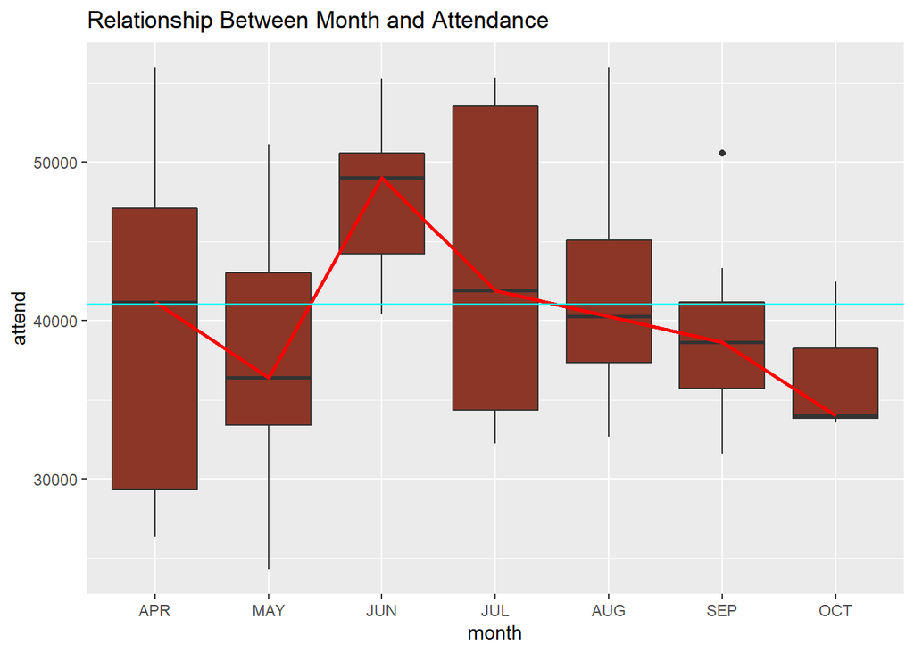

```r
events %>% ggplot(aes(month, attend)) + geom_boxplot( fill="tomato4") +  stat_summary(fun = median,
               geom = "smooth",
               aes(group = 1),
               col = "red") + labs(title="Relationship Between Month and Attendance")+
geom_hline(yintercept = mean(events$attend),col="cyan")
```

It seems like attendance is high in June. After June, it gradually decreases.Blue line indicates the mean of attendance.

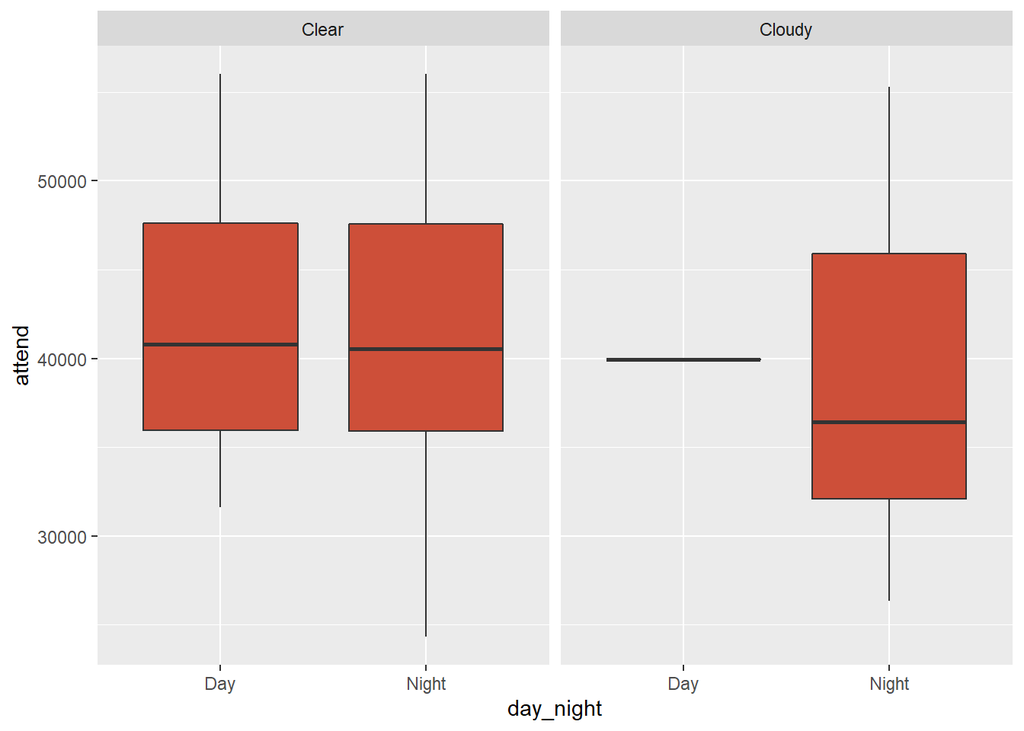

```r
events %>% ggplot(aes(day_night, attend)) + geom_boxplot(fill="tomato3")+facet_wrap(~skies)
```

When it is clear, it seems like it doesn’t matter day or night. Also we have unsufficient data in cloudy days.

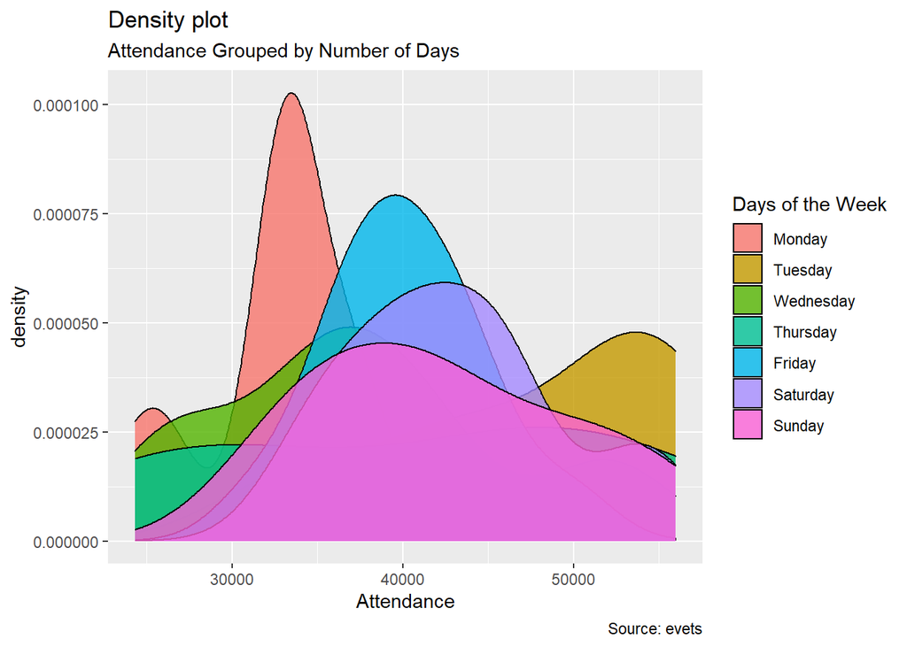

```r
# DENSITY GRAPHH
g <- events %>%  ggplot(aes(attend))
g + geom_density(aes(fill=factor(day_of_week)), alpha=0.8) +
    labs(title="Density plot",
         subtitle="Attendance Grouped by Number of Days",
         caption="Source: evets",
         x="Attendance",
         fill="Days of the Week")
```

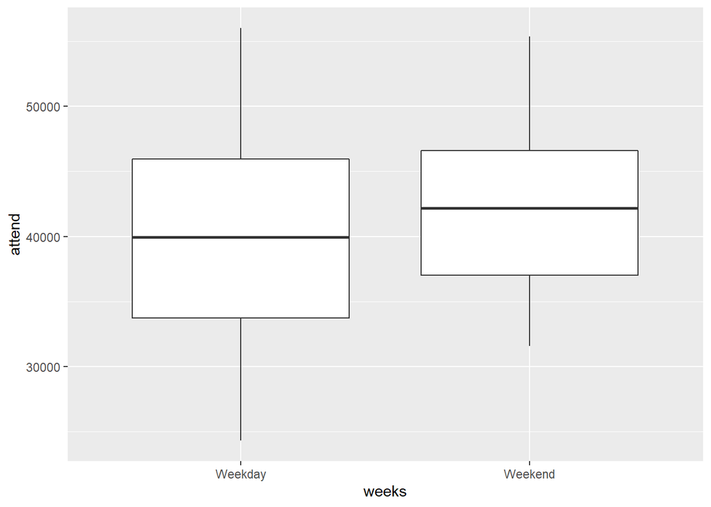

```r
events$weeks <- ifelse(events$day_of_week=="Saturday","Weekend",ifelse(events$day_of_week=="Sunday","Weekend","Weekday"))
events %>% ggplot(aes(attend,weeks))+geom_boxplot()+coord_flip()
```

It seems like attendance is higher in weekends. Let’s see if our hypothesis (attendance and weekdays are independent) is true by applying Chi-square test.

```r
tbl <- xtabs(~ attend+weeks , events)
tbl %>% chisq.test(simulate.p.value = TRUE, B = 10000) %>% pander(caption = "Pearson's Chi-squared test with simulated p-value
     (based on 10000 replicates)")
```

Pearson’s Chi-squared test with simulated p-value (based on 10000 replicates)

| Test statistic | df | P value |
| --- | --- | --- |
| 81 | NA | 0.5562 |

*Hypothesis:* At nights, the weather will be cold, so attendance will be drop.

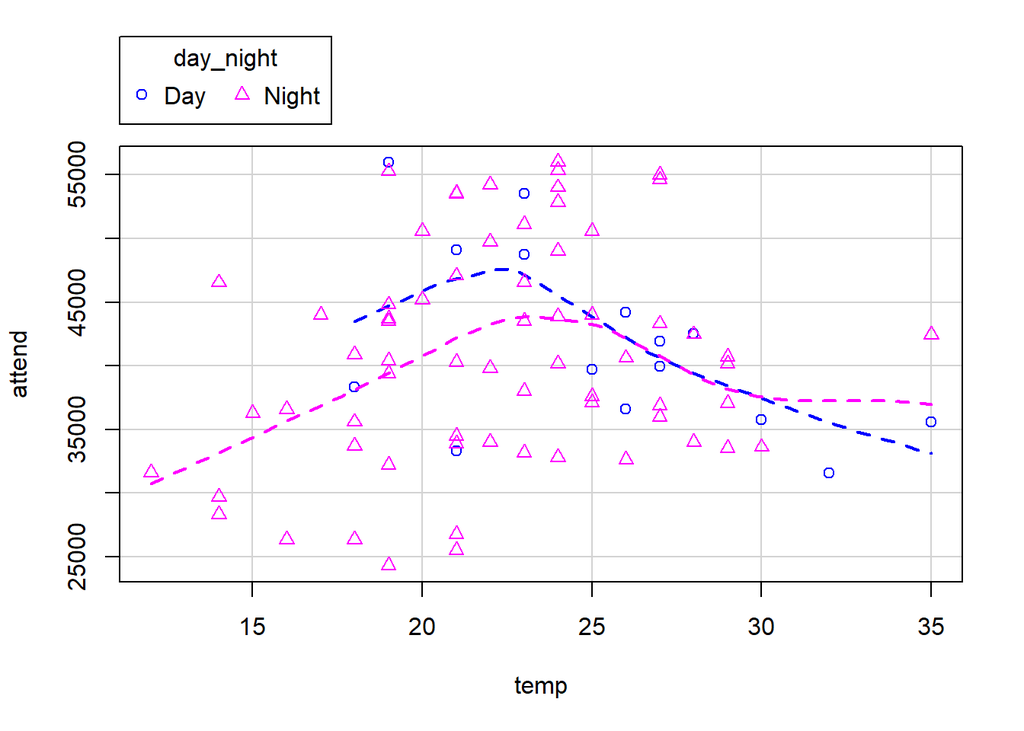

```r
scatterplot(attend ~ temp| day_night, data=events, regLine=FALSE)
```

Our assumption is true that nights are colder and our attendance is lower than night. However when the temperature is higher than the 30 degree, night games are more popular than morning games.

*Hypothesis:* In hotter months, people tend to attend more night games.

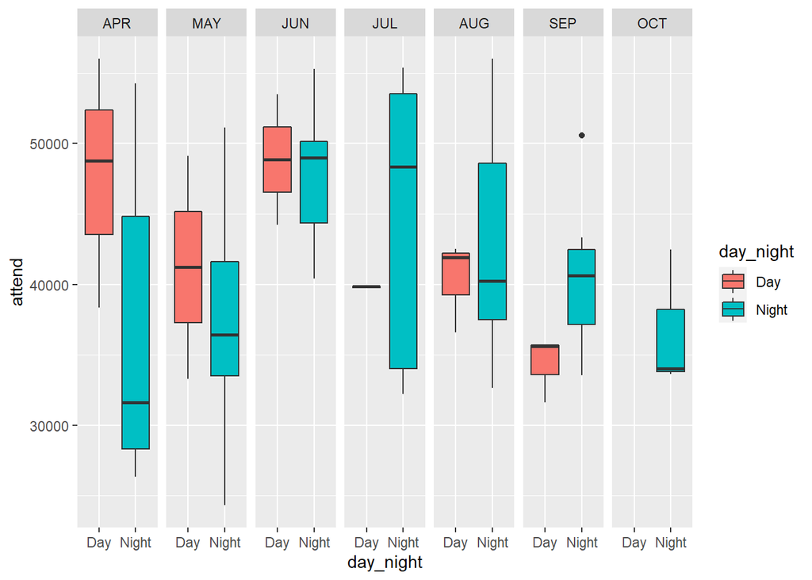

```r
ggplot(events,aes(day_night,attend)) + geom_boxplot(aes(fill=day_night)) + facet_grid(~month)
```

*Hypothesis:* Opponents have an impact on attendance

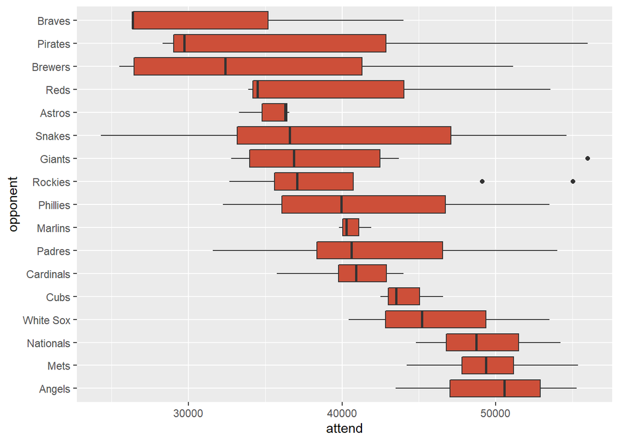

```r
events %>%
  mutate(opponent=fct_reorder(opponent, attend,
                        na.rm=TRUE,
                        .desc=TRUE)) %>% ggplot(aes(opponent, attend)) +
  geom_boxplot(fill="tomato3")+
  coord_flip()
```

It seems like while Angels is the opponent, attendance is the top level, Braves is the opponent, attendance is the low level.

*Hypothesis:* Is there a relationship between day and attendance ?

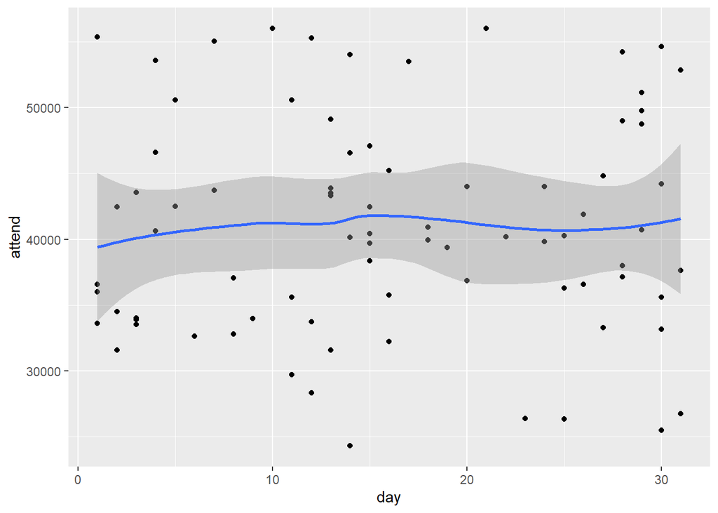

```r
events %>% ggplot(aes(day, attend)) + geom_point( fill="tomato4") +geom_smooth()
```

Since it is kinda straight line, seems like no.

*Hypothesis:* There is a relationship between temp and attendance ?

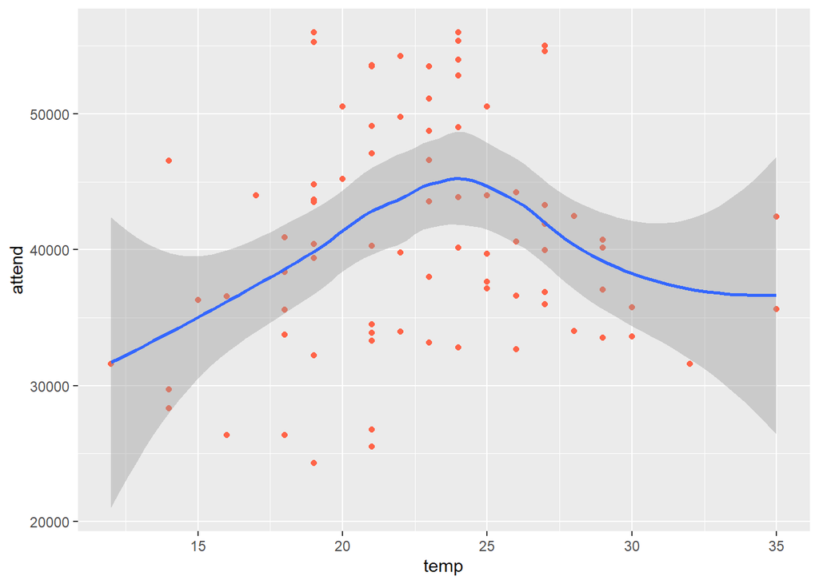

```r
events %>% ggplot(aes(temp, attend)) + geom_point( color="tomato") +geom_smooth()
```

After some degree, attendance starts to go down. But at what degree?

```r
events %>% group_by(temp) %>% summarize_if(is.numeric, max)
```

```
## # A tibble: 20 x 3
##     temp   day attend
##    <dbl> <dbl>  <dbl>
##  1    12    13  31601
##  2    14    14  46549
##  3    15    25  36283
##  4    16    26  36561
##  5    17    24  44014
##  6    18    25  40906
##  7    19    27  56000
##  8    20    16  50559
##  9    21    31  53570
## 10    22    29  54242
## 11    23    30  53504
## 12    24    31  56000
## 13    25    31  50560
## 14    26    30  44217
## 15    27    30  55024
## 16    28     5  42495
## 17    29    29  40724
## 18    30    16  35754
## 19    32     2  31607
## 20    35    30  42449
```

It seems like 24 degree is the maximum point. Lets make further exploration that enable us to use temp variable decently.

```r
tempp<- ifelse(events$temp<=24,events$temp,24-events$temp)
model1<-lm(attend~temp,events)
model2 <- lm(attend~tempp,events)
model3 <- lm(attend~temp+I(temp^2)+I(temp^3)+I(temp^4),events)
model4<- lm(attend~poly(temp,2),events)

BIC(model1,model2,model3,model4)
```

```
##        df      BIC
## model1  3 1703.118
## model2  3 1701.079
## model3  6 1702.130
## model4  4 1698.193
```

When we compare those 4 different model by using BIC and conclude that model 4 provides the most suitable form of temp for our further model. The graph of model 4 seems like as the below. Here important part is following the real temp line without over-fitting.

```r
small<- lm(attend~1,events)
anova(small,model4)
```

```
## Analysis of Variance Table
##
## Model 1: attend ~ 1
## Model 2: attend ~ poly(temp, 2)
##   Res.Df        RSS Df Sum of Sq      F  Pr(>F)
## 1     80 5507932888
## 2     78 4862921988  2 645010899 5.1729 0.00777 **
## ---
## Signif. codes:  0 '***' 0.001 '**' 0.01 '*' 0.05 '.' 0.1 ' ' 1
```

This Anova test shows there is a relationship between quadratic version of temp and attendance.

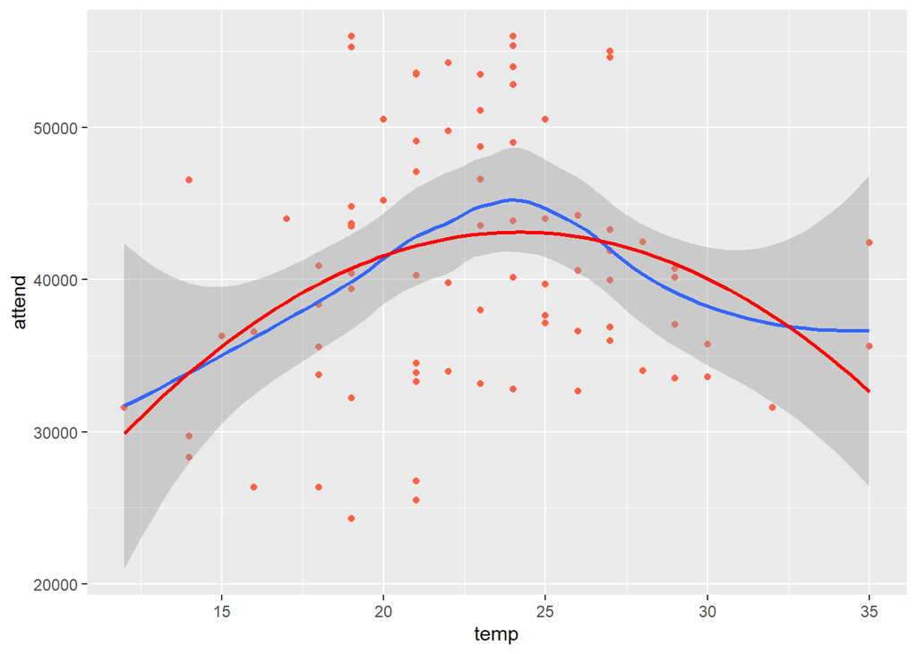

```r
events %>% ggplot(aes(temp,attend)) + geom_point(color="tomato") + geom_smooth() + geom_smooth(method = "lm", formula = y ~ poly(x,2), col="red",se=FALSE)
```

Now lets check

```r
xtabs(attend~day_of_week+day_night,events) %>% summary()
```

```
## Call: xtabs(formula = attend ~ day_of_week + day_night, data = events)
## Number of cases in table: 3324246
## Number of factors: 2
## Test for independence of all factors:
##  Chisq = 1777867, df = 6, p-value = 0
```

When we count the attendance on all games, p-value for the independence test becomes be zero. Therefore, we reject the null hypothesis (= independence of day_night and day of week).Considering sum of attendance, we conclude the predictors day_of_week and day_night are NOT independent. We should consider adding a interaction term to regression model.

Finally, Lets check all the correlations.

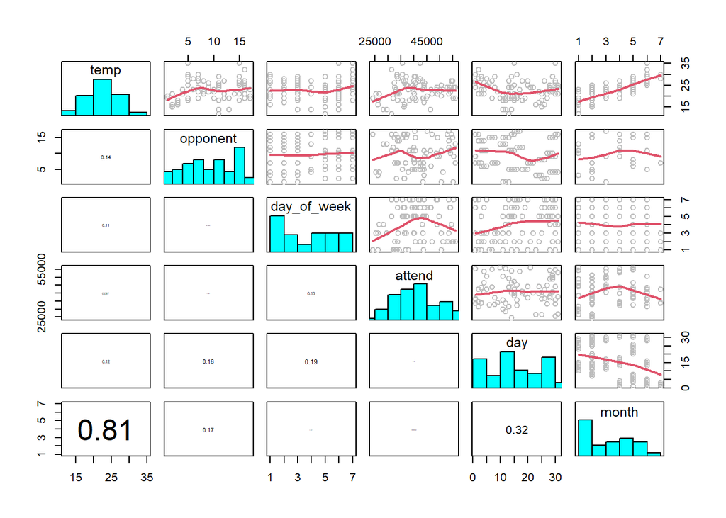

```r
panel.hist <- function(x, ...)
{
    usr <- par("usr"); on.exit(par(usr))
    par(usr = c(usr[1:2], 0, 1.5) )
    h <- hist(x, plot = FALSE)
    breaks <- h$breaks; nB <- length(breaks)
    y <- h$counts; y <- y/max(y)
    rect(breaks[-nB], 0, breaks[-1], y, col = "cyan", ...)
}

panel.cor <- function(x, y, digits = 2, prefix = "", cex.cor, ...)
{
    usr <- par("usr"); on.exit(par(usr))
    par(usr = c(0, 1, 0, 1))
    r <- abs(cor(x, y))
    txt <- format(c(r, 0.123456789), digits = digits)[1]
    txt <- paste0(prefix, txt)
    if(missing(cex.cor)) cex.cor <- 0.8/strwidth(txt)
    text(0.5, 0.5, txt, cex = cex.cor * r)
}

events[1:6] %>%
  rev() %>%
  pairs(diag.panel = panel.hist,
        upper.panel = function(...) panel.smooth(..., lwd=2, col="gray"),
        lower.panel = panel.cor)
```

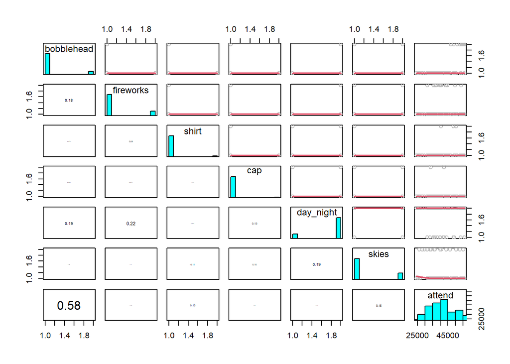

```r
events[c(3,7:12)] %>%
  rev() %>%
  pairs(diag.panel = panel.hist,
        upper.panel = function(...) panel.smooth(..., lwd=2, col="gray"),
        lower.panel = panel.cor)
```

According to correlation results, attendance seems only positive correlated with bobblehead.Attendance seems like only positive correlated wiht bobblehead. Also month is positive correlated with temperature which make sense since April to June, temp will increase gradually. However, correlation between two parameter might cause a problem such as multi-collinearity.

Therefore lets check if there is a multi-collinearity. If vif is greater that 5 or 10 for a particular variable, we suspect that that variable might be explained by other variables and this is what we call multi-collinearity. Since we cannot apply vif directly to categorical variables we used generalized vif value to calculate GVIF^(1/(2*Df)) and come up with a solution.

```r
library(car)
mo<-lm(attend~.-weeks,events)
car::vif(mo)
```

```
##                      GVIF Df GVIF^(1/(2*Df))
## month        15721.683478  6        2.237218
## day              4.122806  1        2.030469
## day_of_week    644.471445  6        1.714353
## opponent    155286.452559 16        1.452857
## temp             9.353453  1        3.058342
## skies            2.316014  1        1.521846
## day_night        4.407191  1        2.099331
## cap              1.878152  1        1.370457
## shirt            1.706222  1        1.306224
## fireworks       22.604096  1        4.754377
## bobblehead       2.728603  1        1.651848
```

Since non of the vif value is bigger than 5, we don’t have to eliminate any of them. So, we can say that there is no multicollinearity.

# 3 Building Model

```r
model<-lm(attend~.-weeks,events)
model %>% summary()
```

```
##
## Call:
## lm(formula = attend ~ . - weeks, data = events)
##
## Residuals:
##     Min      1Q  Median      3Q     Max
## -9071.5 -3105.3   -83.3  1398.1 12467.6
##
## Coefficients:
##                       Estimate Std. Error t value Pr(>|t|)
## (Intercept)           49144.43   14120.70   3.480  0.00114 **
## monthMAY               4562.82    6161.08   0.741  0.46288
## monthJUN              -2780.38   12052.35  -0.231  0.81862
## monthJUL               4725.36    6220.19   0.760  0.45150
## monthAUG               8631.58    7717.22   1.118  0.26943
## monthSEP               4296.83    7739.53   0.555  0.58158
## monthOCT               6217.52    9532.41   0.652  0.51763
## day                     134.00     141.29   0.948  0.34811
## day_of_weekTuesday     8670.34    2943.86   2.945  0.00514 **
## day_of_weekWednesday      6.94    2764.44   0.003  0.99801
## day_of_weekThursday     460.46    3897.62   0.118  0.90650
## day_of_weekFriday    -18358.17    9210.84  -1.993  0.05247 .
## day_of_weekSaturday    3674.93    3341.26   1.100  0.27737
## day_of_weekSunday       892.73    4810.77   0.186  0.85364
## opponentAstros       -20678.17   14211.96  -1.455  0.15277
## opponentBraves       -18497.20   13741.48  -1.346  0.18517
## opponentBrewers      -22322.21   15155.70  -1.473  0.14791
## opponentCardinals    -12532.09   13146.23  -0.953  0.34565
## opponentCubs         -10529.08   12640.84  -0.833  0.40938
## opponentGiants       -16880.09   13263.72  -1.273  0.20983
## opponentMarlins      -19147.75   13897.97  -1.378  0.17525
## opponentMets          -4234.12    6444.47  -0.657  0.51459
## opponentNationals     -5850.86   13928.61  -0.420  0.67649
## opponentPadres       -11169.54   11310.93  -0.988  0.32880
## opponentPhillies     -13698.94   12586.97  -1.088  0.28237
## opponentPirates      -12451.05   13301.72  -0.936  0.35436
## opponentReds         -16473.41   11915.48  -1.383  0.17379
## opponentRockies      -16964.63   12946.55  -1.310  0.19687
## opponentSnakes       -19919.33   12719.45  -1.566  0.12450
## opponentWhite Sox      -928.32    5735.06  -0.162  0.87215
## temp                    -43.20     436.72  -0.099  0.92166
## skiesCloudy            -114.01    2385.81  -0.048  0.96210
## day_nightNight        -3662.30    3590.06  -1.020  0.31325
## capYES                -6503.20    5866.45  -1.109  0.27365
## shirtYES                949.27    4594.60   0.207  0.83727
## fireworksYES          20200.13    8352.77   2.418  0.01980 *
## bobbleheadYES          9395.63    3203.05   2.933  0.00531 **
## ---
## Signif. codes:  0 '***' 0.001 '**' 0.01 '*' 0.05 '.' 0.1 ' ' 1
##
## Residual standard error: 5979 on 44 degrees of freedom
## Multiple R-squared:  0.7145, Adjusted R-squared:  0.4809
## F-statistic: 3.058 on 36 and 44 DF,  p-value: 0.0002485
```

From our first insight we can interpret that since p-value (p < 0.05) is small, our model is significant. Also adjusted `R^2` implies that model explains approximately 48% of variability in expected life which is not good.We are checking adjusted `R^2` since multiple r-square might give us wrong results when the variable number increases in the model. We need to improve more this model. Temp doesn’t seem important but as we discovered earlier, we need to quadratic version of temp.

Coeffients indicates that how many attendance will be gain if we implement those variable. For instance if we give bobblehead, possible attendance that we will get is 9395.

```r
model2<- model %>% update(.~.-temp+poly(temp,2))
model2 %>% summary()
```

```
##
## Call:
## lm(formula = attend ~ month + day + day_of_week + opponent +
##     skies + day_night + cap + shirt + fireworks + bobblehead +
##     poly(temp, 2), data = events)
##
## Residuals:
##    Min     1Q Median     3Q    Max
##  -9792  -2840    -60   1430  11941
##
## Coefficients:
##                      Estimate Std. Error t value Pr(>|t|)
## (Intercept)           54301.4    14233.7   3.815 0.000431 ***
## monthMAY              -1855.0     6983.0  -0.266 0.791777
## monthJUN              -8796.4    12218.7  -0.720 0.475474
## monthJUL              -2726.4     7339.2  -0.371 0.712098
## monthAUG                916.4     8656.7   0.106 0.916189
## monthSEP              -2389.2     8409.1  -0.284 0.777684
## monthOCT              -1335.1    10196.1  -0.131 0.896430
## day                     109.5      138.5   0.790 0.433600
## day_of_weekTuesday     7531.2     2939.8   2.562 0.014001 *
## day_of_weekWednesday   -588.3     2716.3  -0.217 0.829551
## day_of_weekThursday     233.4     3803.5   0.061 0.951359
## day_of_weekFriday    -18459.3     8983.7  -2.055 0.046011 *
## day_of_weekSaturday    4284.2     3276.2   1.308 0.197940
## day_of_weekSunday      1421.0     4701.2   0.302 0.763901
## opponentAstros       -18857.3    13897.9  -1.357 0.181912
## opponentBraves       -22512.1    13585.8  -1.657 0.104794
## opponentBrewers      -22800.6    14784.0  -1.542 0.130342
## opponentCardinals    -12818.3    12822.8  -1.000 0.323070
## opponentCubs         -12207.8    12363.9  -0.987 0.328983
## opponentGiants       -17125.0    12937.1  -1.324 0.192591
## opponentMarlins      -19339.0    13555.4  -1.427 0.160898
## opponentMets          -6281.2     6387.0  -0.983 0.330894
## opponentNationals    -13267.6    14193.2  -0.935 0.355119
## opponentPadres       -12934.4    11075.1  -1.168 0.249286
## opponentPhillies     -12746.4    12287.7  -1.037 0.305379
## opponentPirates      -14281.2    13013.0  -1.097 0.278549
## opponentReds         -16968.9    11624.6  -1.460 0.151632
## opponentRockies      -16922.0    12627.0  -1.340 0.187238
## opponentSnakes       -20252.8    12406.9  -1.632 0.109903
## opponentWhite Sox     -2136.5     5633.5  -0.379 0.706369
## skiesCloudy             744.0     2375.0   0.313 0.755597
## day_nightNight        -2744.0     3538.3  -0.776 0.442269
## capYES                -5421.9     5753.0  -0.942 0.351229
## shirtYES               1016.4     4481.4   0.227 0.821645
## fireworksYES          21232.3     8166.7   2.600 0.012730 *
## bobbleheadYES          9671.9     3127.7   3.092 0.003482 **
## poly(temp, 2)1         9964.3    18989.5   0.525 0.602470
## poly(temp, 2)2       -17123.5     9491.1  -1.804 0.078212 .
## ---
## Signif. codes:  0 '***' 0.001 '**' 0.01 '*' 0.05 '.' 0.1 ' ' 1
##
## Residual standard error: 5831 on 43 degrees of freedom
## Multiple R-squared:  0.7346, Adjusted R-squared:  0.5062
## F-statistic: 3.216 on 37 and 43 DF,  p-value: 0.0001463
```

Lets check whether this model satisfy the normality assumptions.

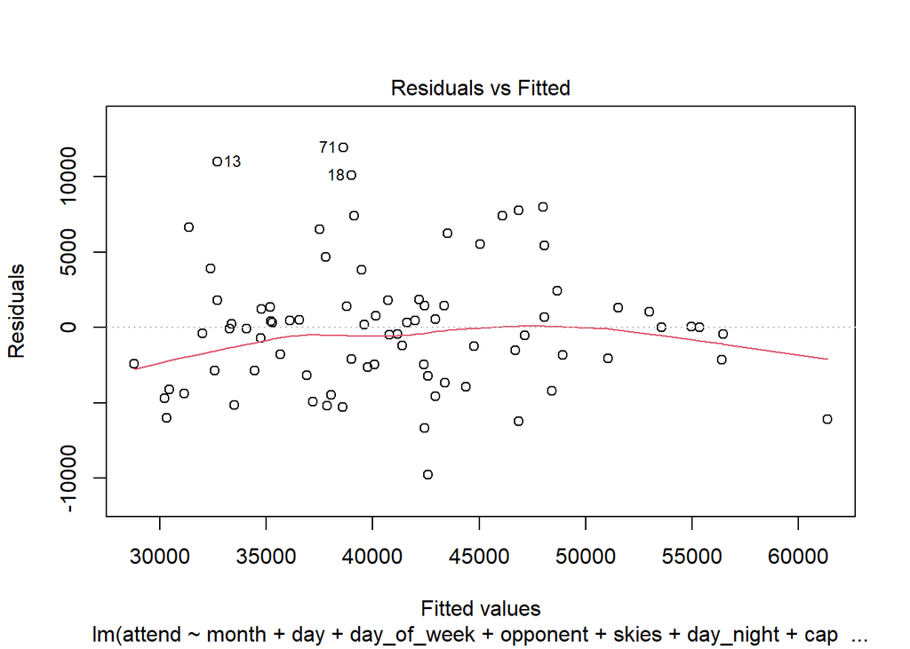

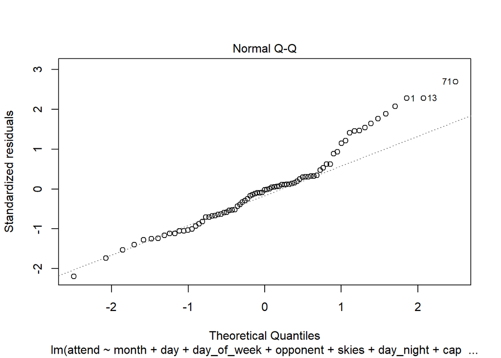

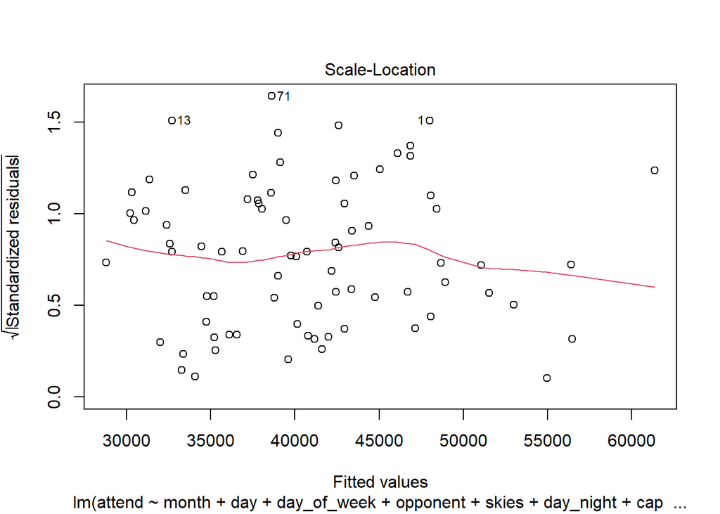

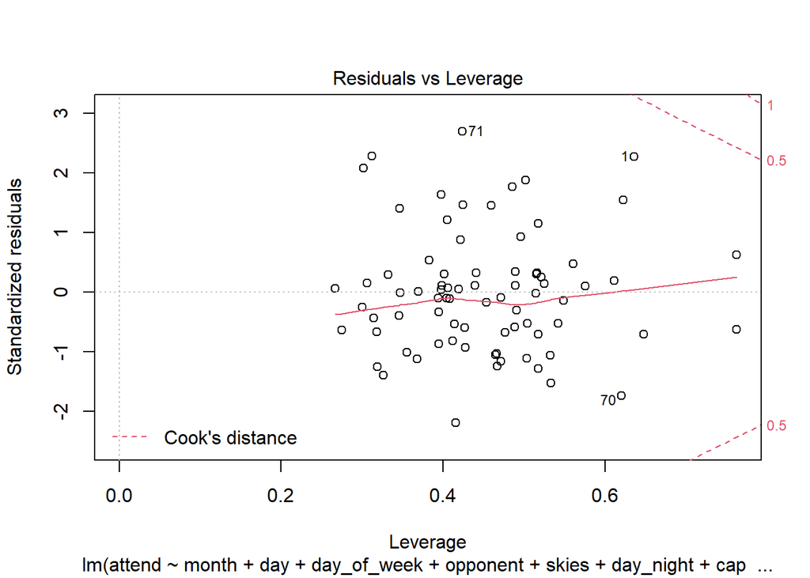

```r
plot(model2)
```

Residual vs Fitted -> Firstly, for the linearity of the model, the Residuals vs. Fitted plot will be checked. It is an indication of correlation between parameters. It doesn’t seem a straight line, so it needs an improvement.

Normal Q-Q plot -> the smoother line again does not follow the dashed line, so it does not satisfy the normality assumption and we expect standardized values to be between -1 and 1 but there are points way beyond 1 and -1.

Scale-Location plot -> Variance is not stable and homoscedasticity assumption is not satisfied.

Residuals vs Leverage -> It seems like there is no influential points.

Conclusion, there is still room for improvement.

Lets add all the interactions and check if our model accuracy increase.

```r
model3<-model2 %>% update(.~.^2)
AIC(model3)
```

```
## [1] -Inf
```

It seems like we over-fitted. Lets check the most important interactions.

```r
model4<- model2 %>% update(.~.+month:poly(temp,2)+opponent:bobblehead+skies:day_night+
                          day_night:day_of_week+ skies:day_of_week+
                            fireworks:day_night+fireworks:shirt)%>% step(trace=FALSE,direction="both")

model5<-model2 %>% update(.~.+month:poly(temp,2)+opponent:bobblehead+skies:day_night+
                          day_night:day_of_week+ skies:day_of_week+
                            fireworks:day_night+fireworks:shirt+day_night:poly(temp, 2)
                          )%>% step(trace=FALSE,direction="both")

model5 %>% summary()
```

```
##
## Call:
## lm(formula = attend ~ month + day + day_of_week + opponent +
##     skies + day_night + shirt + fireworks + bobblehead + poly(temp,
##     2) + month:poly(temp, 2) + opponent:bobblehead + skies:day_night +
##     day_of_week:day_night + day_of_week:skies + day_night:poly(temp,
##     2), data = events)
##
## Residuals:
##     Min      1Q  Median      3Q     Max
## -4483.7  -867.9     0.0   834.1  5471.0
##
## Coefficients: (14 not defined because of singularities)
##                                       Estimate Std. Error t value Pr(>|t|)
## (Intercept)                            39215.2    31534.4   1.244 0.232745
## monthMAY                               49899.3    22189.4   2.249 0.039981 *
## monthJUN                              -20756.5    38178.9  -0.544 0.594661
## monthJUL                              -42548.2    22459.3  -1.894 0.077609 .
## monthAUG                               45022.0    20982.6   2.146 0.048672 *
## monthSEP                               59917.7    20910.9   2.865 0.011794 *
## monthOCT                              101527.9    33912.4   2.994 0.009086 **
## day                                     -154.0      152.9  -1.007 0.329969
## day_of_weekTuesday                     -1675.3    15513.6  -0.108 0.915434
## day_of_weekWednesday                  -12781.3    12806.3  -0.998 0.334084
## day_of_weekThursday                    -1320.9     4019.8  -0.329 0.746999
## day_of_weekFriday                     -19688.0     7882.4  -2.498 0.024616 *
## day_of_weekSaturday                    41461.3    48014.8   0.864 0.401454
## day_of_weekSunday                      -5627.8    11218.0  -0.502 0.623179
## opponentAstros                        -29858.4    22163.9  -1.347 0.197927
## opponentBraves                         26862.7    26053.8   1.031 0.318857
## opponentBrewers                       -15093.5    24849.7  -0.607 0.552674
## opponentCardinals                     -11399.9    21647.7  -0.527 0.606165
## opponentCubs                          -18947.0    20652.7  -0.917 0.373444
## opponentGiants                        -11366.3    22566.4  -0.504 0.621802
## opponentMarlins                       -18049.1    22085.1  -0.817 0.426576
## opponentMets                           -8345.8    10041.7  -0.831 0.418942
## opponentNationals                      30882.9    27022.0   1.143 0.271004
## opponentPadres                          2796.5    20598.0   0.136 0.893813
## opponentPhillies                       10490.7    21786.2   0.482 0.637091
## opponentPirates                        16921.3    23043.1   0.734 0.474071
```

[output cut: 45 more lines]

```
## day_of_weekSunday:day_nightNight            NA         NA      NA       NA
## day_of_weekTuesday:skiesCloudy         30780.1     9081.8   3.389 0.004046 **
## day_of_weekWednesday:skiesCloudy        7464.1     6354.6   1.175 0.258465
## day_of_weekThursday:skiesCloudy         4888.7     9534.7   0.513 0.615610
## day_of_weekFriday:skiesCloudy          12523.3     6952.8   1.801 0.091805 .
## day_of_weekSaturday:skiesCloudy        29772.3     7549.2   3.944 0.001300 **
## day_of_weekSunday:skiesCloudy               NA         NA      NA       NA
## day_nightNight:poly(temp, 2)1          67075.3    52511.1   1.277 0.220895
## day_nightNight:poly(temp, 2)2         -10941.8    37987.9  -0.288 0.777263
## ---
## Signif. codes:  0 '***' 0.001 '**' 0.01 '*' 0.05 '.' 0.1 ' ' 1
##
## Residual standard error: 4641 on 15 degrees of freedom
## Multiple R-squared:  0.9413, Adjusted R-squared:  0.6871
## F-statistic: 3.703 on 65 and 15 DF,  p-value: 0.003481
```

We obtain our Adjusted R-squared 69% which is better than our first model. Lets compare our first model and more developed model.

```r
AIC(model2,model4,model5)
```

```
##        df      AIC
## model2 39 1661.268
## model4 65 1612.855
## model5 67 1594.994
```

```r
BIC(model2,model4,model5)
```

```
##        df      BIC
## model2 39 1754.651
## model4 65 1768.495
## model5 67 1755.422
```

AIC and BIC measures the goodness of fit however it seems like they are not agree on the same model. While AIC choose model 5 (most complicated model), BIC choose model 2(least complicated model among other models that we created).

```r
100*sigma(model2)/median(events$attend)
```

```
## [1] 14.47471
```

```r
100*sigma(model4)/median(events$attend)
```

```
## [1] 12.38602
```

```r
100*sigma(model5)/median(events$attend)
```

```
## [1] 11.52137
```

Also our error percentage has been declined from %14 (model2) to %11 (model5). However since we have very limited data, we may over-fit things so it would be safer if we do cross-validation.

```r
nfold <-  4
set.seed(1)
id_fold <- rep(1:4, len = nrow(events)) %>% sample()

rmse_model2 <- rep(NA, nfold)
rmse_model4 <- rep(NA, nfold)
rmse_model5 <- rep(NA, nfold)
for (i in seq(nfold)){
  test <- events[id_fold == i,]
  train <- events[id_fold != i,]

  lmod_2 <- update(model2, data = train)
  suppressWarnings(pred_test_2 <- predict(lmod_2, newdata= test))
  rmse_model2[i] <- sqrt(mean((test$attend - pred_test_2)^2))

  lmod_4 <- update(model4, data = train)
  suppressWarnings(pred_test_4 <- predict(lmod_4, newdata= test))
  rmse_model4[i] <- sqrt(mean((test$attend - pred_test_4)^2))

  lmod_5 <- update(model5, data = train)
  suppressWarnings(pred_test_5 <- predict(lmod_5, newdata= test))
  rmse_model5[i] <- sqrt(mean((test$attend - pred_test_5)^2))
}

rmse_model2 %>% mean()
```

```
## [1] 11189.82
```

```r
rmse_model4 %>% mean()
```

```
## [1] 109652.5
```

```r
rmse_model5 %>% mean()
```

```
## [1] 210005.2
```

Maybe we can think simpler and come up with a simple model. Lets directly apply stepwise selection to model2 and come up with a simpler solution.

```r
simple <- model2 %>% step(direction="backward",trace=FALSE)
summary(simple)
```

```
##
## Call:
## lm(formula = attend ~ month + day_of_week + cap + fireworks +
##     bobblehead + poly(temp, 2), data = events)
##
## Residuals:
##     Min      1Q  Median      3Q     Max
## -9846.2 -3615.1  -155.4  2571.6 14080.7
##
## Coefficients:
##                      Estimate Std. Error t value             Pr(>|t|)
## (Intercept)           36657.1     2913.9  12.580 < 0.0000000000000002 ***
## monthMAY              -4903.9     2393.6  -2.049             0.044652 *
## monthJUN               4142.6     2922.4   1.418             0.161251
## monthJUL              -1461.5     3056.3  -0.478             0.634168
## monthAUG               -790.6     3278.5  -0.241             0.810221
## monthSEP              -2423.7     4019.8  -0.603             0.548716
## monthOCT              -3382.6     4954.4  -0.683             0.497270
## day_of_weekTuesday     8120.8     2567.8   3.163             0.002407 **
## day_of_weekWednesday    719.9     2383.6   0.302             0.763639
## day_of_weekThursday     853.7     3228.9   0.264             0.792352
## day_of_weekFriday    -11759.9     6645.5  -1.770             0.081633 .
## day_of_weekSaturday    6782.7     2363.5   2.870             0.005586 **
## day_of_weekSunday      6828.9     2463.6   2.772             0.007317 **
## capYES                -5594.3     4379.6  -1.277             0.206172
## fireworksYES          16938.8     6159.5   2.750             0.007768 **
## bobbleheadYES          9648.5     2342.0   4.120             0.000113 ***
## poly(temp, 2)1         7415.2    11590.9   0.640             0.524658
## poly(temp, 2)2       -16763.6     6899.2  -2.430             0.017969 *
## ---
## Signif. codes:  0 '***' 0.001 '**' 0.01 '*' 0.05 '.' 0.1 ' ' 1
##
## Residual standard error: 5632 on 63 degrees of freedom
## Multiple R-squared:  0.6372, Adjusted R-squared:  0.5393
## F-statistic: 6.508 on 17 and 63 DF,  p-value: 0.00000001656
```

This simple model has better `adj-R^2` than model2. Let’s compare AIC and BIC.

```r
AIC(model2,simple)
```

```
##        df      AIC
## model2 39 1661.268
## simple 19 1646.586
```

```r
BIC(model2,simple)
```

```
##        df      BIC
## model2 39 1754.651
## simple 19 1692.080
```

Both method indicates that simple model is better. To be sure lets do cross-validation again.

```r
nfold <-  4
set.seed(1)
id_fold <- rep(1:4, len = nrow(events)) %>% sample()

rmse_model2 <- rep(NA, nfold)
rmse_simple <- rep(NA, nfold)

for (i in seq(nfold)){
  test <- events[id_fold == i,]
  train <- events[id_fold != i,]

  lmod_2 <- update(model2, data = train)
  suppressWarnings(pred_test_2 <- predict(lmod_2, newdata= test))
  rmse_model2[i] <- sqrt(mean((test$attend - pred_test_2)^2))

  lmod_4 <- update(simple, data = train)
  suppressWarnings(pred_test_4 <- predict(lmod_4, newdata= test))
  rmse_simple[i] <- sqrt(mean((test$attend - pred_test_4)^2))

}

rmse_model2 %>% mean()
```

```
## [1] 11189.82
```

```r
rmse_simple %>% mean()
```

```
## [1] 7337.389
```

Also according to cross validation results, simple model works better in unseen data. All method indicates that simple model is the best among all of the models.

```r
summary(simple)
```

```
##
## Call:
## lm(formula = attend ~ month + day_of_week + cap + fireworks +
##     bobblehead + poly(temp, 2), data = events)
##
## Residuals:
##     Min      1Q  Median      3Q     Max
## -9846.2 -3615.1  -155.4  2571.6 14080.7
##
## Coefficients:
##                      Estimate Std. Error t value             Pr(>|t|)
## (Intercept)           36657.1     2913.9  12.580 < 0.0000000000000002 ***
## monthMAY              -4903.9     2393.6  -2.049             0.044652 *
## monthJUN               4142.6     2922.4   1.418             0.161251
## monthJUL              -1461.5     3056.3  -0.478             0.634168
## monthAUG               -790.6     3278.5  -0.241             0.810221
## monthSEP              -2423.7     4019.8  -0.603             0.548716
## monthOCT              -3382.6     4954.4  -0.683             0.497270
## day_of_weekTuesday     8120.8     2567.8   3.163             0.002407 **
## day_of_weekWednesday    719.9     2383.6   0.302             0.763639
## day_of_weekThursday     853.7     3228.9   0.264             0.792352
## day_of_weekFriday    -11759.9     6645.5  -1.770             0.081633 .
## day_of_weekSaturday    6782.7     2363.5   2.870             0.005586 **
## day_of_weekSunday      6828.9     2463.6   2.772             0.007317 **
## capYES                -5594.3     4379.6  -1.277             0.206172
## fireworksYES          16938.8     6159.5   2.750             0.007768 **
## bobbleheadYES          9648.5     2342.0   4.120             0.000113 ***
## poly(temp, 2)1         7415.2    11590.9   0.640             0.524658
## poly(temp, 2)2       -16763.6     6899.2  -2.430             0.017969 *
## ---
## Signif. codes:  0 '***' 0.001 '**' 0.01 '*' 0.05 '.' 0.1 ' ' 1
##
## Residual standard error: 5632 on 63 degrees of freedom
## Multiple R-squared:  0.6372, Adjusted R-squared:  0.5393
## F-statistic: 6.508 on 17 and 63 DF,  p-value: 0.00000001656
```

# 4 Analysis

Lets check if our model suggest that there is relation between attend and at least one of the other variables?

```r
anova(update(simple, . ~ 1), simple)
```

```
## Analysis of Variance Table
##
## Model 1: attend ~ 1
## Model 2: attend ~ month + day_of_week + cap + fireworks + bobblehead +
##     poly(temp, 2)
##   Res.Df        RSS Df  Sum of Sq      F        Pr(>F)
## 1     80 5507932888
## 2     63 1998485144 17 3509447744 6.5077 0.00000001656 ***
## ---
## Signif. codes:  0 '***' 0.001 '**' 0.01 '*' 0.05 '.' 0.1 ' ' 1
```

We test model with intercept only against the working model. F test has practically zero p-value. We reject the null model. There is strong evidence in the data to support that at least one of the predictors is related to response.

Also we can check the most significant significant main effects in our model

```r
summary(simple) %>%
  coef() %>%
  as_tibble(rownames = "Predictor") %>%
  arrange(`Pr(>|t|)`) %>%
  pander(caption = "Effects")
```

Effects

| Predictor | Estimate | Std. Error | t value | Pr(>\|t\|) |
| --- | --- | --- | --- | --- |
| (Intercept) | 36657 | 2914 | 12.58 | 0.0000000000000000007681 |
| bobbleheadYES | 9648 | 2342 | 4.12 | 0.0001126 |
| day_of_weekTuesday | 8121 | 2568 | 3.163 | 0.002407 |
| day_of_weekSaturday | 6783 | 2364 | 2.87 | 0.005586 |
| day_of_weekSunday | 6829 | 2464 | 2.772 | 0.007317 |
| fireworksYES | 16939 | 6160 | 2.75 | 0.007768 |
| poly(temp, 2)2 | -16764 | 6899 | -2.43 | 0.01797 |
| monthMAY | -4904 | 2394 | -2.049 | 0.04465 |
| day_of_weekFriday | -11760 | 6645 | -1.77 | 0.08163 |
| monthJUN | 4143 | 2922 | 1.418 | 0.1613 |
| capYES | -5594 | 4380 | -1.277 | 0.2062 |
| monthOCT | -3383 | 4954 | -0.6827 | 0.4973 |
| poly(temp, 2)1 | 7415 | 11591 | 0.6397 | 0.5247 |
| monthSEP | -2424 | 4020 | -0.6029 | 0.5487 |
| monthJUL | -1462 | 3056 | -0.4782 | 0.6342 |
| day_of_weekWednesday | 719.9 | 2384 | 0.302 | 0.7636 |
| day_of_weekThursday | 853.7 | 3229 | 0.2644 | 0.7924 |
| monthAUG | -790.6 | 3279 | -0.2412 | 0.8102 |

It seems like the most significant main effect is bobblehead.

Let’s do some quick analysis. For instance, if we want to predict the attendance in June friday while temp is avearge and no cap or bobblehead is given.

[output not shown]